# 190121 Session3

보아즈 시각화

2019년 1월 21일

### 시나리오

- 최근까지 당신의 회사에 근무하는 직원들과 전 국민이 최저 임금인상을 놓고 논쟁을 벌여왔다.
- 임금을 시급으로 받는 직원이 많기에 앞으로 정부가 강제하는 인상안이 비용에 어떤 영향을 미칠지, 그 결과에 대응해야 한다

### 구현사항

- 정부가 강제할 것이라 예상되는 최저 임금 인상안을 기반으로 한 부서별 인건비 증가액을 보여줘야 한다
- 임금 분포와 최저 임금이 그에 미치는 영향이 어떤지를 살펴봐야 한다
- 회사는 얼마나 많은 직원이 영향을 받는지, 최소 5년간 근속한 직원에게 지급할 ’표준 생활비’를 마련하는데 얼마나 비용이 들지 알고자 한다

### 데이터 읽기

```r
### 데이터 읽기
wage <- fread("C:/Users/HS/Desktop/Wage Analysis.csv", encoding = "UTF-8")
wage <- tbl_df(wage)


str(wage)
```

```
## Classes 'tbl_df', 'tbl' and 'data.frame':    917 obs. of  14 variables:
##  $ Below or Above               : chr  "Above" "Above" "Above" "Above" ...
##  $ Budget Area                  : chr  "Services" "Supply Chain" "Operations" "Services" ...
##  $ Below Minimum Wage           : chr  "Above Minimum Wage" "Above Minimum Wage" "Above Minimum Wage" "Above Minimum Wage" ...
##  $ Wage Correction              : chr  "-$24,050.8" "-$16,356.2" "-$25,059.3" "-$18,386.8" ...
##  $ Hrly Correction              : chr  "$24.02" "$21.13" "$24.39" "$21.89" ...
##  $ Hrly Rate Bin Size           : chr  "$24.00" "$21.00" "$24.00" "$21.00" ...
##  $ Hrly Correction (bin)        : chr  "$24.00" "$21.00" "$24.00" "$21.00" ...
##  $ Hrly Rate (bin)              : chr  "$24.00" "$21.00" "$24.00" "$21.00" ...
##  $ Hrly Rate Correction Bin Size: chr  "$24.00" "$21.00" "$24.00" "$21.00" ...
##  $ Hrly Rate                    : chr  "$24.02" "$21.13" "$24.39" "$21.89" ...
##  $ ID                           : int  771 166 193 280 475 674 902 447 125 474 ...
##  $ 레코드 수                    : int  1 1 1 1 1 1 1 1 1 1 ...
##  $ Service Dt                   : chr  "1979-04-30" "1979-08-28" "1980-01-07" "1980-02-15" ...
##  $ Service Time in Years        : num  36.5 36.1 35.8 35.7 34.5 ...
##  - attr(*, ".internal.selfref")=<externalptr>
```

```r
head(wage)
```

```
## # A tibble: 6 x 14
##   `Below or Above` `Budget Area` `Below Minimum Wage` `Wage Correction`
##   <chr>            <chr>         <chr>                <chr>
## 1 Above            Services      Above Minimum Wage   -$24,050.8
## 2 Above            Supply Chain  Above Minimum Wage   -$16,356.2
## 3 Above            Operations    Above Minimum Wage   -$25,059.3
## 4 Above            Services      Above Minimum Wage   -$18,386.8
## 5 Below            Facilities    Below Minimum Wage   $5,344.5
## 6 Above            Facilities    Above Minimum Wage   -$20,276.6
## # ... with 10 more variables: `Hrly Correction` <chr>, `Hrly Rate Bin
## #   Size` <chr>, `Hrly Correction (bin)` <chr>, `Hrly Rate (bin)` <chr>,
## #   `Hrly Rate Correction Bin Size` <chr>, `Hrly Rate` <chr>, ID <int>,
## #   `레코드 수` <int>, `Service Dt` <chr>, `Service Time in Years` <dbl>
```

### 전처리

```r
# 변수명 바꾸기
# 띄어쓰기를 _ 로 사용
x<-names(wage)
names(wage) <- as.vector(
  sapply(x, function(x) if(is.character(x)) gsub(" ", "\\_", x) else(x)))

# 변수형태
# date, nummeric
# "$", "," 사인제거
x1 <- wage[4]
x1 <- as.vector(sapply(x1, function(x1) if(is.character(x1)) gsub(",", "", x1) else(x1)))
wage[4] <- as.vector(sapply(x1, function(x1) if(is.character(x1)) gsub("\\$", "", x1) else(x1)))
# number, date parsing
wage[4:10] <- as.tibble(lapply(wage[4:10], parse_number))
wage[13] <- as.tibble(lapply(wage[13], parse_date))
```

### 데이터 확인

```r
wage %>% print(width = Inf)
```

```
## # A tibble: 917 x 14
##    Below_or_Above Budget_Area     Below_Minimum_Wage Wage_Correction
##    <chr>          <chr>           <chr>                        <dbl>
##  1 Above          Services        Above Minimum Wage         -24051.
##  2 Above          Supply Chain    Above Minimum Wage         -16356.
##  3 Above          Operations      Above Minimum Wage         -25059.
##  4 Above          Services        Above Minimum Wage         -18387.
##  5 Below          Facilities      Below Minimum Wage           5344.
##  6 Above          Facilities      Above Minimum Wage         -20277.
##  7 Above          Services        Above Minimum Wage         -28622.
##  8 Above          Finance         Above Minimum Wage         -22982.
##  9 Above          Human Resources Above Minimum Wage         -18552.
## 10 Below          Facilities      Below Minimum Wage           5344.
##    Hrly_Correction Hrly_Rate_Bin_Size `Hrly_Correction_(bin)`
##              <dbl>              <dbl>                   <dbl>
```

[output cut: 35 more lines]

## 1. 평균근속연수별 시급

- 연속형 x : Service_Time_in_Year (평균근속연수)
- 연속형 y : Hrly_Rate (시급)

```r
# 데이터상 기본 최저시급 15 달러를 기준으로 below/above 구분
wage %>% group_by(Below_Minimum_Wage) %>% count()
```

```
## # A tibble: 2 x 2
## # Groups:   Below_Minimum_Wage [2]
##   Below_Minimum_Wage     n
##   <chr>              <int>
## 1 Above Minimum Wage   621
## 2 Below Minimum Wage   296
```

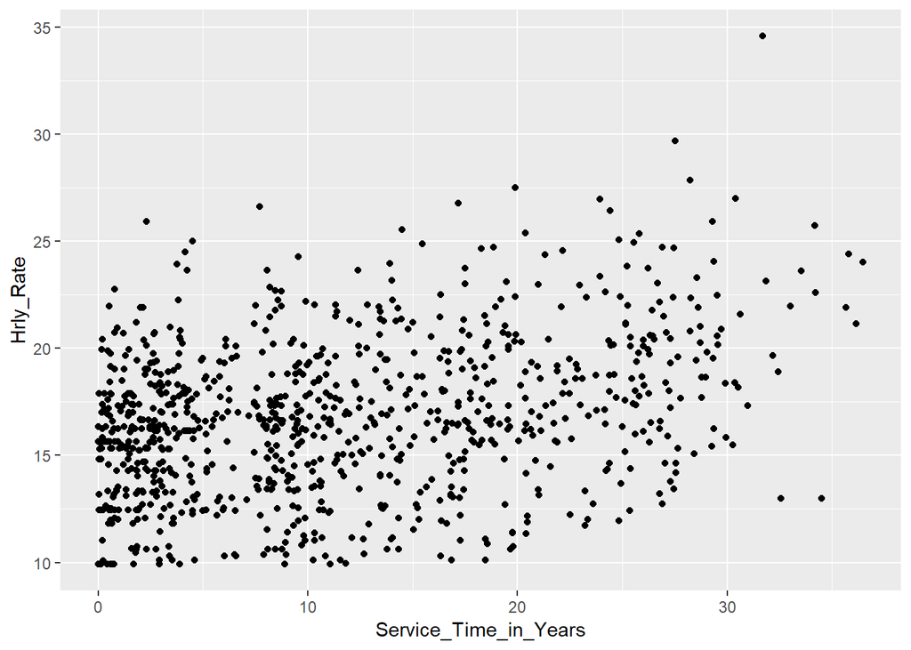

```r
# 평균근속연수와 시급 산점도
wage %>% ggplot(aes(Service_Time_in_Years, Hrly_Rate)) + geom_point()
```

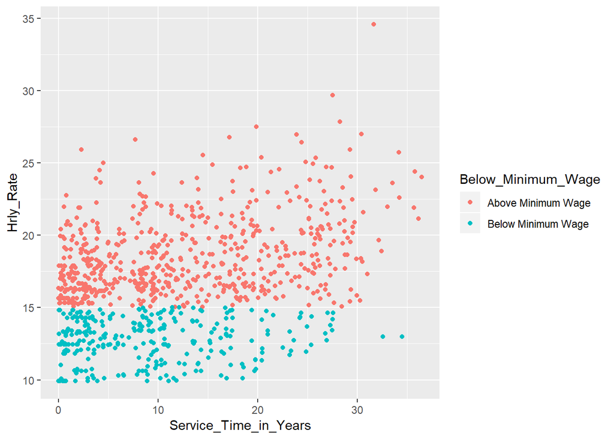

```r
# 최저임금보다 적게받는지 많이 받는지 (below/above) 색상 추가
# aes(color = Below_Minimum_Wage) 옵션
wage %>% ggplot(aes(Service_Time_in_Years, Hrly_Rate, color = Below_Minimum_Wage)) + geom_point()
```

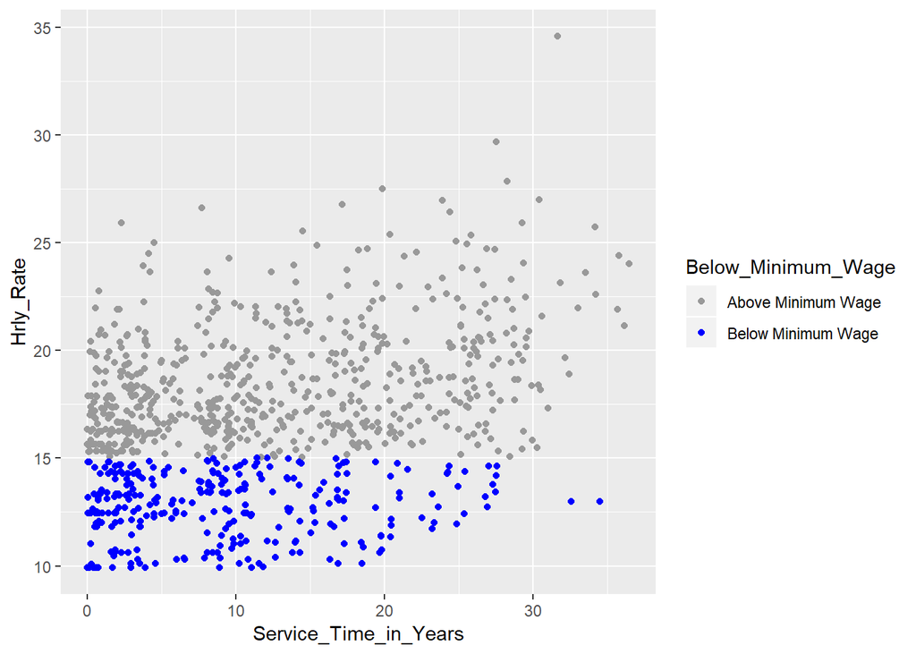

```r
# color 옵션을 사용자 지정 scale_color_manual
# 파란색은 최저임금 인상시 영향을 받을 사람
wage %>% ggplot(aes(Service_Time_in_Years, Hrly_Rate, color = Below_Minimum_Wage)) + geom_point() +
  scale_color_manual(values = c("grey60", "blue"))  # color 옵션을 사용자 지정
```

### (1)산점도

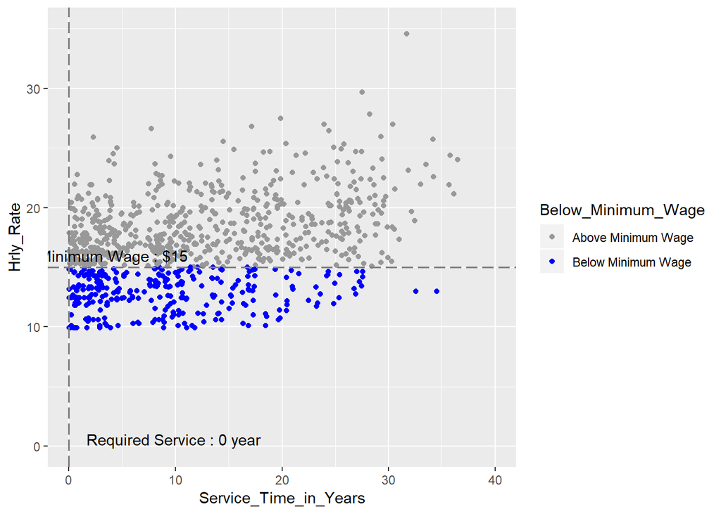

```r
# 평균근속연수와 시급
wage %>% ggplot(aes(Service_Time_in_Years, Hrly_Rate, color = Below_Minimum_Wage)) + geom_point() +
  geom_vline(xintercept = 0, linetype = "longdash", color="grey50", size=0.7) +   # 세로선  geom_vline
  geom_hline(yintercept = 15, linetype = "longdash", color="grey50", size=0.7) +  # 가로선  geom_hline
  annotate("text", x = 0, y = 0, label = "Required Service : 0 year", hjust = -0.1, vjust = -0.1) +  # 텍스트 주석  annotate("text", label=)
  annotate("text", x = 0, y = 15, label = "Minimum Wage : $15", hjust = 0.2, vjust = -0.5) +  # 텍스트 주석  annotate("text", label=)
  lims(x = c(0,40), y = c(0, 35)) +  # x축, y축 범위 조정 lims(x, y), xlim(), ylim()
  scale_color_manual(values = c("grey60", "blue"))  # color 옵션을 사용자지정
```

## 2. 부서의 영향을 보여주는 막대 차트

- 이중막대 차트는 부서별로 세분화된 금액, 인력 수의 영향을 모두 표시한다
- 막대는 금액을 기준으로 내림차순으로 정렬된다.

```r
# 최저임금 조정시 부서별 영향 집계
b <- wage %>% filter(Below_Minimum_Wage == "Below Minimum Wage") %>%   # 최저임금 이하의 직원
  group_by(Budget_Area) %>%    # 부서별 집계
  summarise(sum_Wage_Correction = sum(Wage_Correction), # 최저임금의 금전적 영향
            sum_Record = sum(`레코드_수`)) %>%          # 최저임금 미만의 직원
  arrange(desc(sum_Wage_Correction))   # 내림차순으로 정렬
b
```

```
## # A tibble: 12 x 3
##    Budget_Area            sum_Wage_Correction sum_Record
##    <chr>                                <dbl>      <int>
##  1 Services                           812377.        131
##  2 Facilities                         730562.         93
##  3 Marketing                           84480.         23
##  4 Logistics                           50630.         15
##  5 Supply Chain                        37988.         13
##  6 Legal                               27191.          4
##  7 Operations                          12265.          3
##  8 Customer Service                    10923.          4
##  9 Information Technology               8760.          3
## 10 Human Resources                      7539.          4
## 11 Purchasing                           4272.          1
## 12 Research & Development               1818.          2
```

```r
# gather() 함수로 measure 변수 안에 "sum_Wage_Correction", "sum_Record" 을 범주로 할당
# facet_warp 을 사용하기 위함
endatalong <- gather(b, key = "measure", value = "value", c("sum_Wage_Correction", "sum_Record"))
endatalong %>% print(n = Inf)
```

```
## # A tibble: 24 x 3
##    Budget_Area            measure               value
##    <chr>                  <chr>                 <dbl>
##  1 Services               sum_Wage_Correction 812377.
##  2 Facilities             sum_Wage_Correction 730562.
##  3 Marketing              sum_Wage_Correction  84480.
##  4 Logistics              sum_Wage_Correction  50630.
##  5 Supply Chain           sum_Wage_Correction  37988.
##  6 Legal                  sum_Wage_Correction  27191.
##  7 Operations             sum_Wage_Correction  12265.
##  8 Customer Service       sum_Wage_Correction  10923.
##  9 Information Technology sum_Wage_Correction   8760.
## 10 Human Resources        sum_Wage_Correction   7539.
## 11 Purchasing             sum_Wage_Correction   4272.
## 12 Research & Development sum_Wage_Correction   1818.
## 13 Services               sum_Record             131
## 14 Facilities             sum_Record              93
## 15 Marketing              sum_Record              23
## 16 Logistics              sum_Record              15
## 17 Supply Chain           sum_Record              13
## 18 Legal                  sum_Record               4
## 19 Operations             sum_Record               3
## 20 Customer Service       sum_Record               4
## 21 Information Technology sum_Record               3
## 22 Human Resources        sum_Record               4
## 23 Purchasing             sum_Record               1
## 24 Research & Development sum_Record               2
```

### (2)부서별막대차트

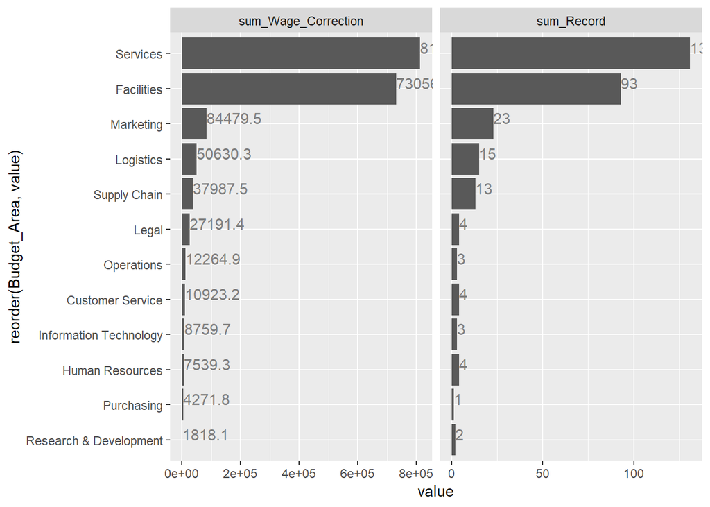

```r
endatalong %>%
  transform( measure = factor(measure, levels = c("sum_Wage_Correction", "sum_Record"))) %>%  # facet 상 순서를 바꾸기 위해 levels 범주 순서 바꿈
  # ggplot 생성
  ggplot(aes(reorder(Budget_Area, value), value)) +  # 부서별 value 를 내림차순으로 정렬
  # geom
  geom_bar(stat= "identity") +                       # bar
  geom_text(aes(label = value), vjust = 0, hjust = 0, color = "grey50") + # value 값을 label로 생성
  facet_wrap(~measure, scale = "free_x") +  # 데이터를 여러 개의 부분집합으로 나누고( measure 범주별 ) 작은 여러 개의 그래프 생성
  # coord
  coord_flip()   # coord_flip()은 x축과 y축의 구성을 뒤집어 표현하라는 명령어
```

```r
                 # coord_flip은 데이터를 기반으로 하지 않고, bar그래프에 대한 함수도 아니기 때문에 ggplot과 geom_bar 함수 뒤에 레이어 추가 형식으로 지정
```

## 현재의 분포와 그 전망치를 보여주는 히스토그램

히스토그램과 연관된 정규 분포는 현재 분포, 분포 전망을 나타낸다

```r
wage %>% group_by(Hrly_Rate_Bin_Size) %>% count() %>% print(n = Inf)
```

```
## # A tibble: 21 x 2
## # Groups:   Hrly_Rate_Bin_Size [21]
##    Hrly_Rate_Bin_Size     n
##                 <dbl> <int>
##  1                  9    16
##  2                 10    34
##  3                 11    34
##  4                 12    70
##  5                 13    64
##  6                 14    78
##  7                 15    87
##  8                 16   129
##  9                 17   106
## 10                 18    68
## 11                 19    69
## 12                 20    53
## 13                 21    38
## 14                 22    25
## 15                 23    16
## 16                 24    13
## 17                 25     8
## 18                 26     5
## 19                 27     2
## 20                 29     1
## 21                 34     1
```

# 3. 현재 임금과 인력 수의 분포

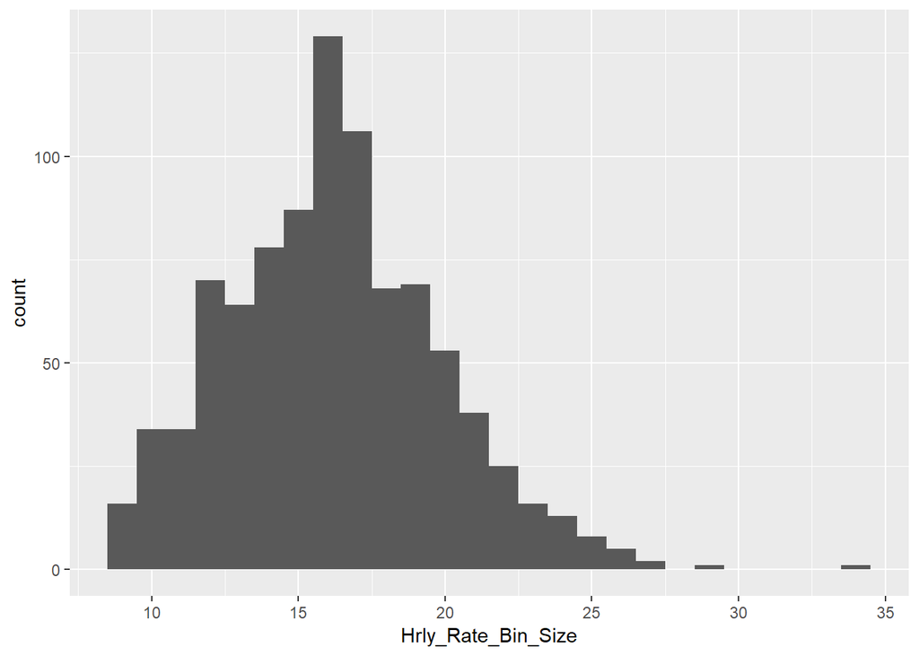

```r
# 히스토그램
wage %>%
  ggplot(aes(Hrly_Rate_Bin_Size)) + geom_histogram(binwidth = 1)
```

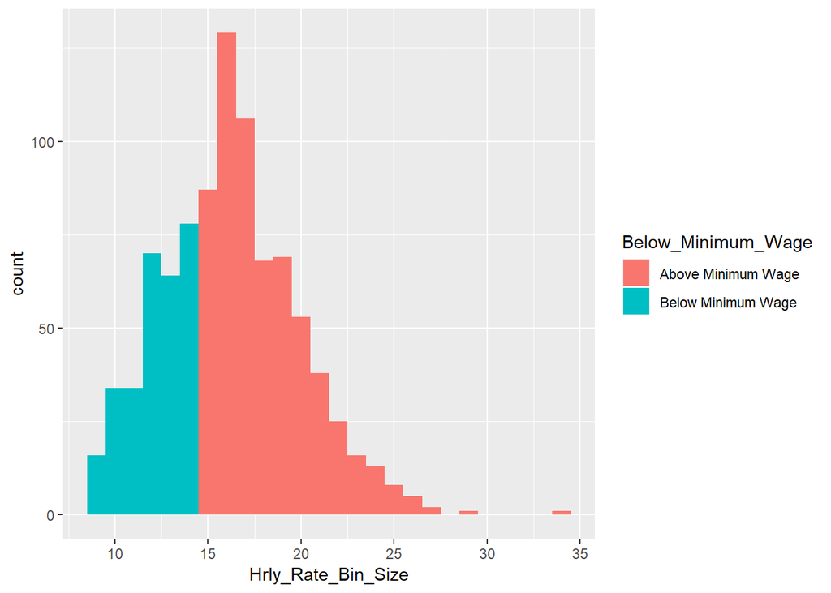

```r
# 최저임금보다 적게받는지 많이 받는지 (below/above) 색상 추가
# aes(fill = Below_Minimum_Wage) 옵션
wage %>%
  ggplot(aes(x = Hrly_Rate_Bin_Size)) +
  geom_histogram(aes(fill = Below_Minimum_Wage), binwidth = 1)
```

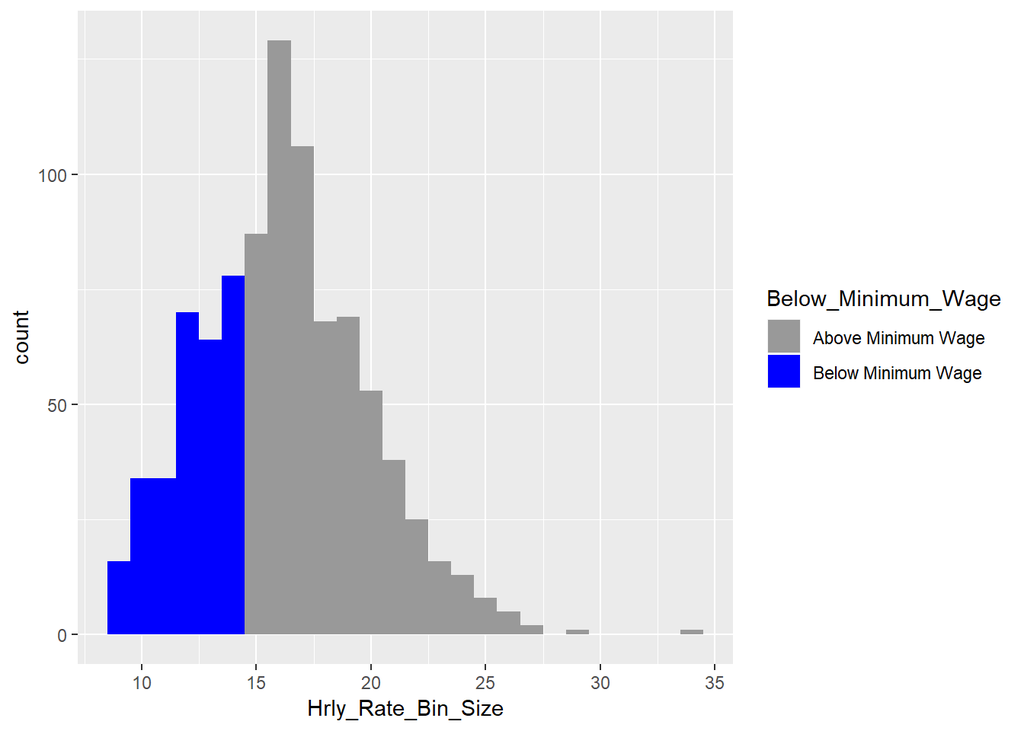

```r
# fill 옵션 사용자 지정 scale_fill_manual()
# 파란색은 최저임금 인상시 영향을 받을 사람
wage %>%
  ggplot(aes(x = Hrly_Rate_Bin_Size)) +
  geom_histogram(aes(fill = Below_Minimum_Wage), binwidth = 1) +
  scale_fill_manual(values = c("grey60", "blue"))  # fill 옵션 사용자 지정
```

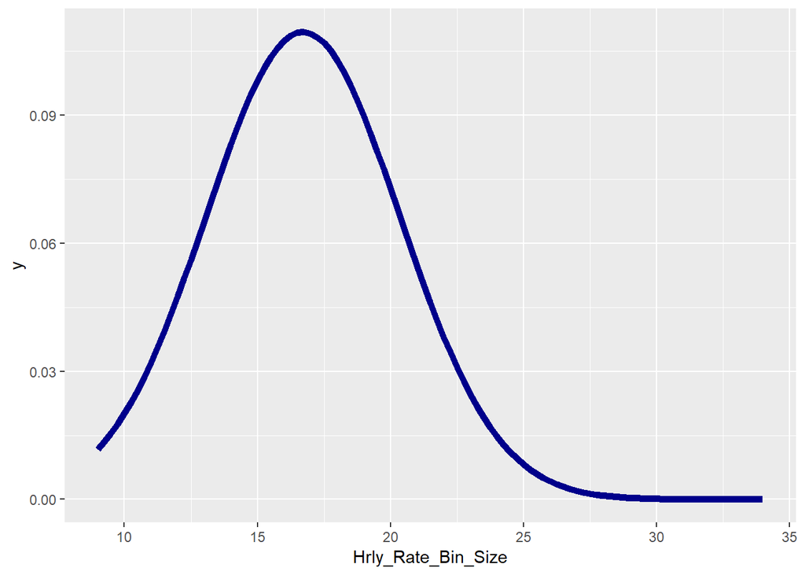

```r
# 정규분포그래프
ggplot(data = wage, aes(Hrly_Rate_Bin_Size)) +
  stat_function(fun = dnorm,
                args = list(mean = mean(wage$Hrly_Rate), sd= sd(wage$Hrly_Rate)),
                color = "darkblue", size = 2)
```

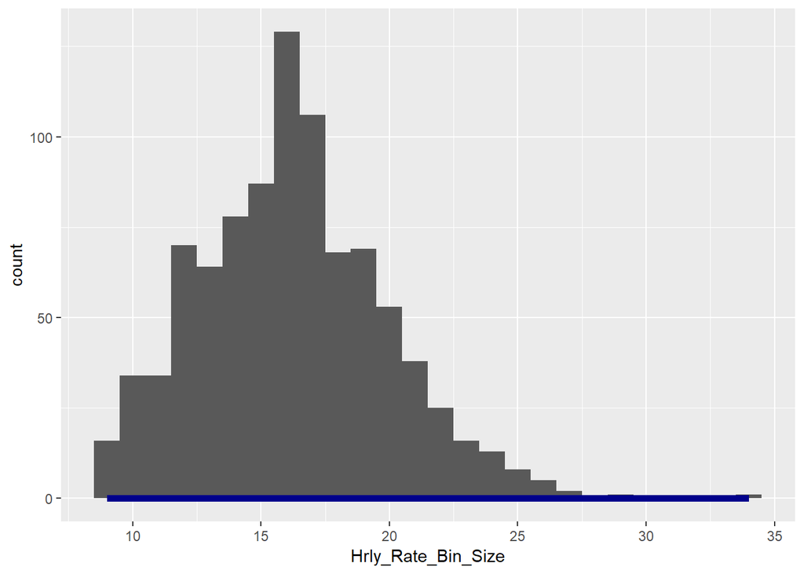

```r
# 한번에 그려보기! 하지만....
# y축 스케일 범위가 달라서 사용하지 못한다
wage %>%
  ggplot(aes(Hrly_Rate_Bin_Size)) +
  geom_histogram(binwidth = 1) +
  stat_function(fun = dnorm, args = list(mean = mean(wage$Hrly_Rate), sd= sd(wage$Hrly_Rate)),
                color = "darkblue", size = 2)
```

### 이중축 그리기

#### (3)정규분포 곡선이 있는 히스토그램 그래프1

##### parameters that will be passed to `stat_function`

```r
n = nrow(wage)  # 917
mean = mean(wage$Hrly_Rate)  # 16.70716
sd = sd(wage$Hrly_Rate)  #3.642373
binwidth = 1  # 막대사이즈
# passed to geom_histogram and stat_function

# wage 데이터에 정규분포 데이터 추가
set.seed(1)
wage <- wage %>% mutate(x = rnorm(n, mean, sd))
names(wage)
```

```
##  [1] "Below_or_Above"                "Budget_Area"
##  [3] "Below_Minimum_Wage"            "Wage_Correction"
##  [5] "Hrly_Correction"               "Hrly_Rate_Bin_Size"
##  [7] "Hrly_Correction_(bin)"         "Hrly_Rate_(bin)"
##  [9] "Hrly_Rate_Correction_Bin_Size" "Hrly_Rate"
## [11] "ID"                            "레코드_수"
## [13] "Service_Dt"                    "Service_Time_in_Years"
## [15] "x"
```

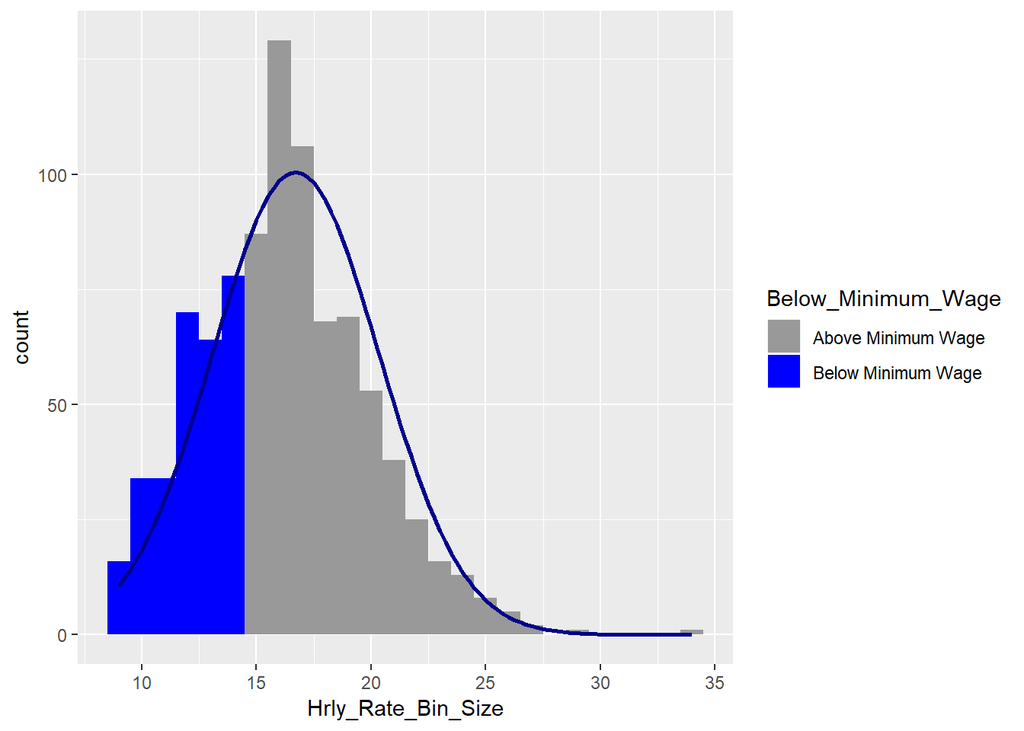

```r
## 히스토그램과 정규분포그래프
wage %>%
  ggplot(aes(x = Hrly_Rate_Bin_Size)) +
  geom_histogram(aes(fill = Below_Minimum_Wage), binwidth = binwidth) +
  stat_function(fun = function(x) dnorm(x, mean = mean, sd = sd) * n * binwidth,
                color = "darkblue", size = 1) +
  scale_fill_manual(values = c("grey60", "blue"))
```

#### 4. 최소근속연수

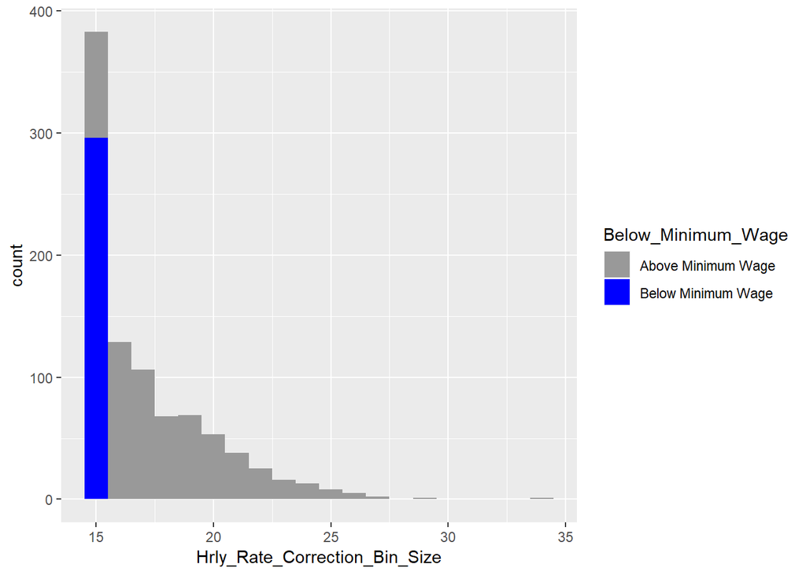

```r
# 히스토그램
wage %>%
  ggplot(aes(Hrly_Rate_Correction_Bin_Size)) +
  geom_histogram(aes(fill = Below_Minimum_Wage), binwidth = 1) +
  scale_fill_manual(values = c("grey60", "blue"))
```

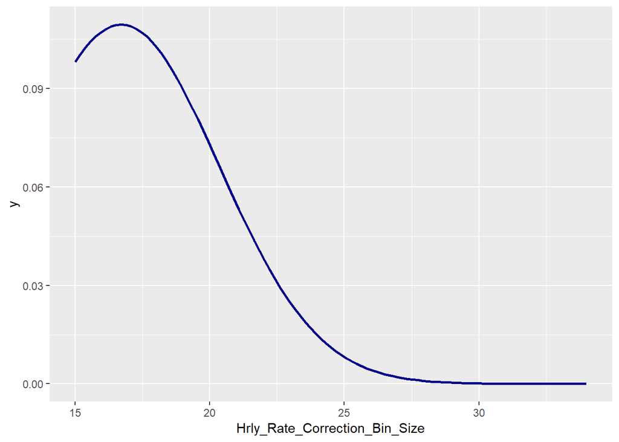

```r
# 정규분포곡선1
# y 축 스케일 안맞음
ggplot(data = wage, aes(Hrly_Rate_Correction_Bin_Size)) +
  stat_function(fun = dnorm, args = list(mean = mean(wage$Hrly_Rate), sd= sd(wage$Hrly_Rate)),
                color = "darkblue", size = 1)
```

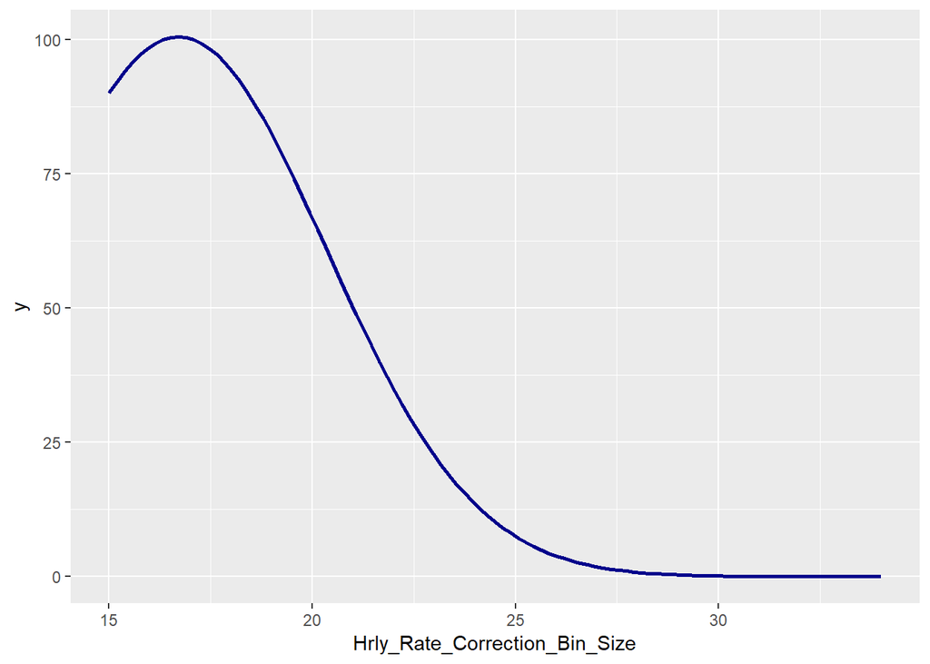

```r
# 정규분포곡선2
# passed to geom_histogram and stat_function
ggplot(data = wage, aes(Hrly_Rate_Correction_Bin_Size)) +
  stat_function(fun = function(x) dnorm(x, mean = mean, sd = sd) * n * binwidth,
                color = "darkblue", size = 1)
```

### (4)정규분포 곡선이 있는 히스토그램 그래프2

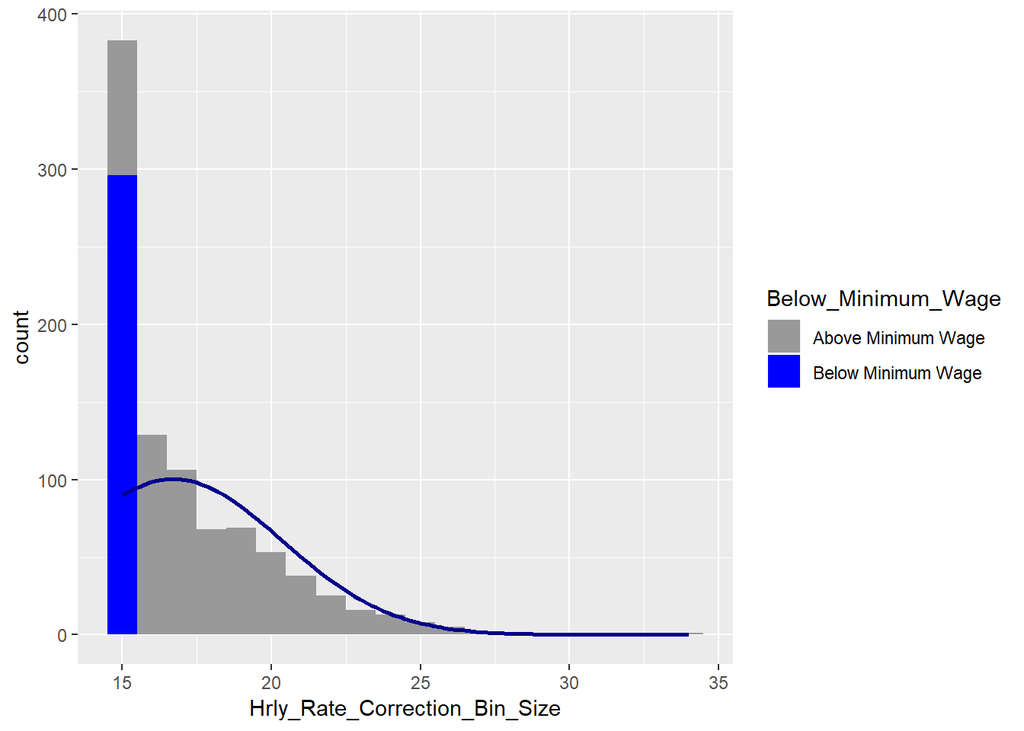

```r
ggplot(wage, aes(x = Hrly_Rate_Correction_Bin_Size)) +
  geom_histogram(aes(fill = Below_Minimum_Wage), binwidth = binwidth) +
  stat_function(fun = function(x) dnorm(x, mean = mean, sd = sd) * n * binwidth,
                color = "darkblue", size = 1) +
  scale_fill_manual(values = c("grey60", "blue"))
```

## 추가

### (생략) 볼사람만

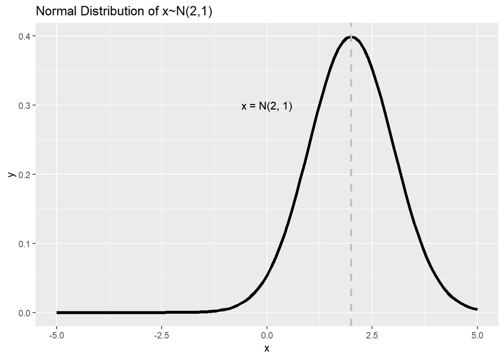

```r
# 정규분포: 평균과 분산 지정
# (1/(sqrt([STDEV]^2*2*pi()))) * exp(-( (attr([Hrly Rate Bin Size])-[Mean])^2  /  (2*[STDEV]^2)  )) * 1 * TOTAL(SUM([레코드 수]))

ggplot(data.frame(x = c(-5, 5)), aes(x=x)) +
  stat_function(fun=dnorm, args=list(mean=2, sd=1), colour="black", size=1.5) +
  geom_vline(xintercept=2, colour="grey", linetype="dashed", size=1) + # 평균에 세로 직선 추가
  geom_text(x=0, y=0.3, label="x = N(2, 1)") +
  ggtitle("Normal Distribution of x~N(2,1)")
```

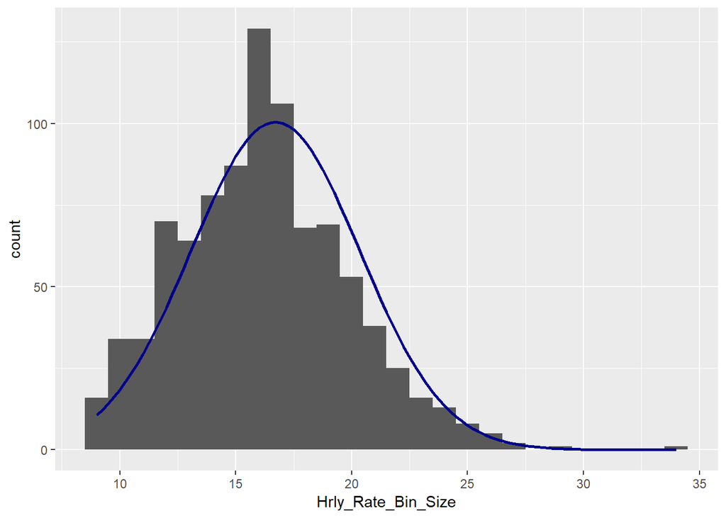

```r
# 출처: http://rfriend.tistory.com/95 [R, Python 분석과 프로그래밍 (by R Friend)]

# 이중축 그리기

ggplot(wage, aes(x = Hrly_Rate_Bin_Size)) +
  geom_histogram(binwidth = binwidth) +
  stat_function(fun = function(x) dnorm(x, mean = mean, sd = sd)*n*binwidth,
                color = "darkblue", size = 1)
```

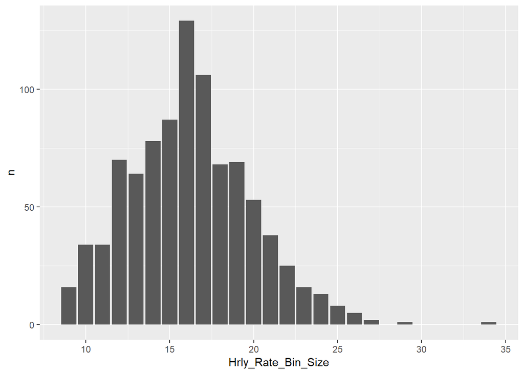

```r
# https://stackoverflow.com/questions/6967664/ggplot2-histogram-with-normal-curve

# bar
# bar chart
# 그리는 3가지 방법
wage %>% group_by(Hrly_Rate_Bin_Size) %>% count() %>%
  ggplot(aes(Hrly_Rate_Bin_Size, n)) + geom_bar(stat = "identity")
```

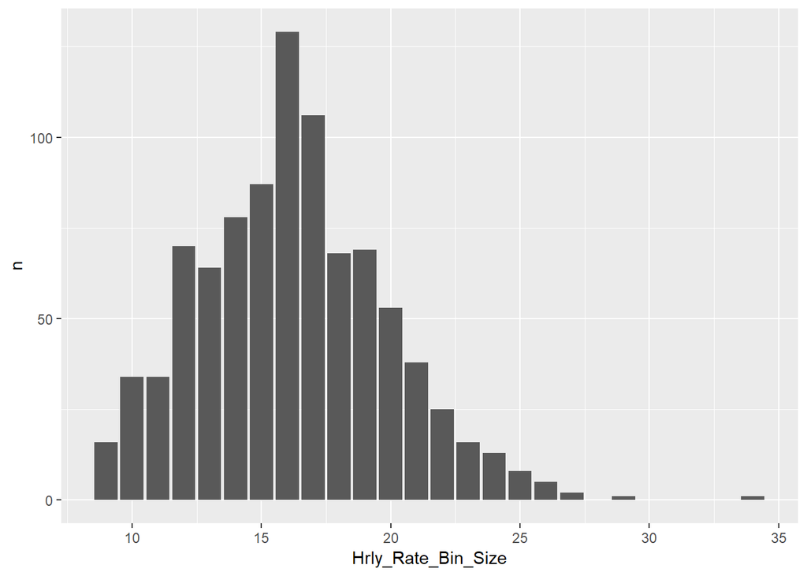

```r
wage %>% group_by(Hrly_Rate_Bin_Size) %>% count() %>%
  ggplot(aes(Hrly_Rate_Bin_Size, n)) + geom_col()
```

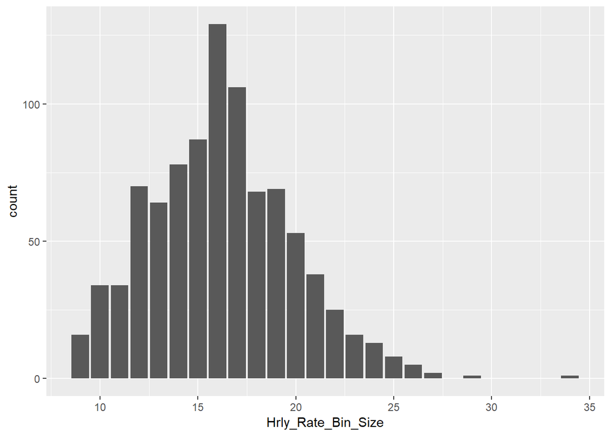

```r
wage %>%
  ggplot(aes(Hrly_Rate_Bin_Size)) + geom_bar(stat = "count")
```

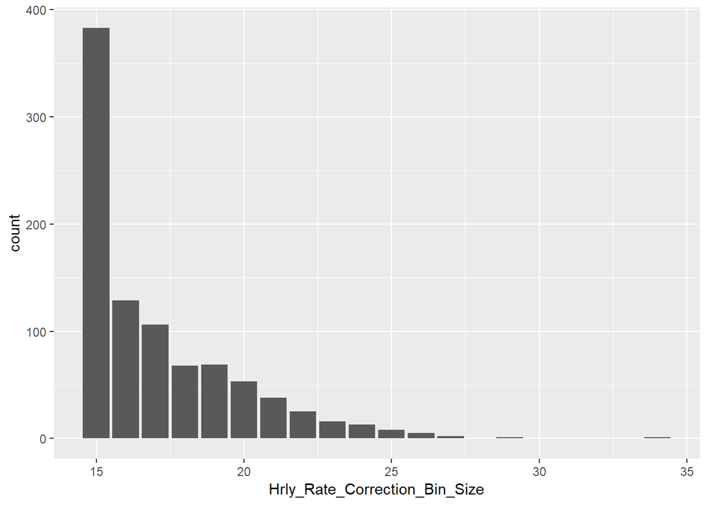

```r
wage %>%
  ggplot(aes(Hrly_Rate_Correction_Bin_Size)) + geom_bar(stat = "count")
```

# 과제

## 1. bar 차트와 histogram 의 차이 설명과 예시

## 2. 최저임금 17, 최소근속연수 4 일 때 그래프 4개 그리기

## 3. (추가) 동적으로 구현해보기

## 구현사항 할사람만,,,

```r
minimum_wage <- 17     # 최저임금 조정
required_service <- 4   # 최소근속연수 조정

#새로운 임금, 근속연수 조정 후 Below/Above 재설정 -> NEW 변수, NEW_wage 데이터셋
NEW_wage <- wage %>% mutate(NEW = ifelse(Hrly_Rate < minimum_wage & Service_Time_in_Years > required_service,
                                         "Below Minimum Wage", "Above Minimum Wage"))

# ((2)부서별 bar 차트 그리기 위한 데이터셋)
c <- NEW_wage %>% filter(NEW == "Below Minimum Wage") %>%   # 최저임금 이하의 직원
  group_by(Budget_Area) %>%    # 부서별 집계
  summarise(sum_Wage_Correction = sum(Wage_Correction), # 최저임금의 금전적 영향
            sum_Record = sum(`레코드_수`)) %>%          # 최저임금 미만의 직원
  arrange(desc(sum_Wage_Correction))   # 내림차순으로 정렬
endatalong <- gather(c, key = "measure", value = "value", c("sum_Wage_Correction", "sum_Record"))
endatalong
```

```
## # A tibble: 28 x 3
##    Budget_Area            measure                value
##    <chr>                  <chr>                  <dbl>
##  1 Facilities             sum_Wage_Correction  370483.
##  2 Services               sum_Wage_Correction  310118.
##  3 Legal                  sum_Wage_Correction   27191.
##  4 Logistics              sum_Wage_Correction   14158.
##  5 Human Resources        sum_Wage_Correction    5751.
##  6 Finance                sum_Wage_Correction    -226.
##  7 Purchasing             sum_Wage_Correction    -978.
##  8 Customer Service       sum_Wage_Correction   -4094.
##  9 Information Technology sum_Wage_Correction   -6329.
## 10 Research & Development sum_Wage_Correction   -7103.
## # ... with 18 more rows
```

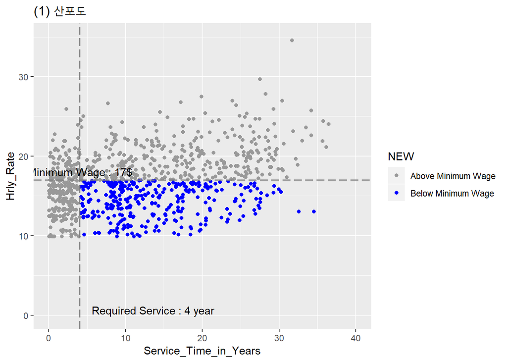

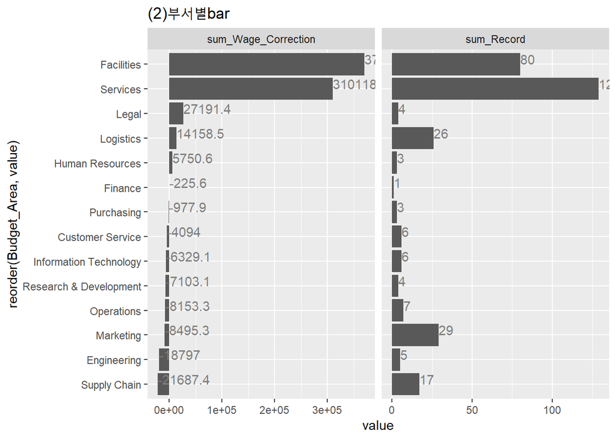

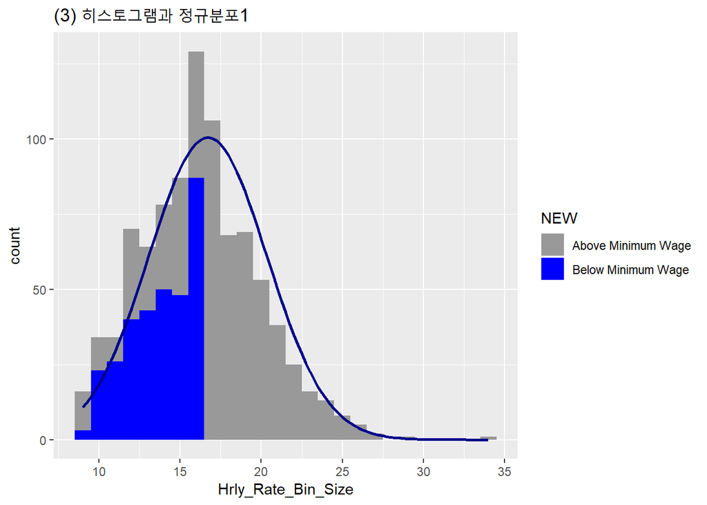

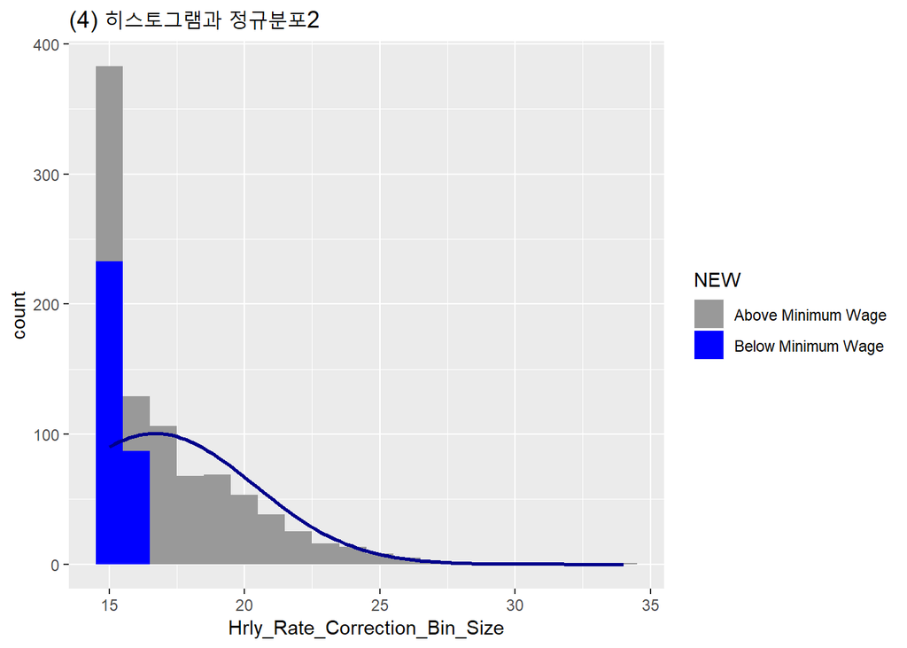